# Machine Learning to utilize the data of wearable devices

Yoshihiro Ueda

## Summary

The purpose of this report is to utilize wearable device data to predict the activity of the wearer. The training data contains sensed data from the human body and given 5 activity classes for his/her activities. The model from the training data will be applied to the testing data to predict the activity class for each record. The modeling method used here is CART. The accuracy for this model is 0.497. Final submission shows that only 8 of 20 predictions are correct.

## The data

Two data sets are used in this report.

- for training: pml-training.csv - 19622 records with 160 columns
- for testing: pml-testing.csv - 20 records with the same 160 columns

The data uded in this report come from the source: “Human Activity Recognition” (http://groupware.les.inf.puc-rio.br/har) by Groupware@LES: group of research and development of groupware technologies.

Here I would like to express my appreciation to their generosity in allowing their data to be used for this kind of assignment.

The training data contains sensed data from the human body and labelled his/her activity as “A” to “E” in the coulmn “classe”. The testing data has the same format in spite that it doesn’t contain the activity label, which is left to be predicted.

## Preparation

First, the data files are assumed to be downloaded and stored in /data/ subdirectory of the working directory.

```r
library(caret, verbose = FALSE)
# setwd("~/Projects/PracticalMachineLearning/assignment/")
pml.training <- read.csv("./data/pml-training.csv")
pml.testing <- read.csv("./data/pml-testing.csv")
```

## Preprocessing

The training data seems to have many fields that don’t seem to contribute classify, i.e. whose values seem to be the same. Here the testing data has more such fields. These fields can be detected using nearZeroVar function.

```r
# removing variables not affect learning
nzv <- nearZeroVar(pml.testing,saveMetrics=TRUE)
usecolumns <- colnames (pml.training) [!nzv$nzv]
```

Note: In actual cases, the testing data is not unknown and it is not appropriate to remove the nearZeroVar varibalesin the testing set.

Also the record name, user name, timestamp and window info should not be included in the training data (even id they may contribute the learning).

Addinitionally, I have removed several variables (“pitch_belt”, etc.) which made the fit fail.

```r
usecolumns <- usecolumns[-c(1:6)] # record name, user name, timestamp and windows
usecolumns <- usecolumns[is.na(match(usecolumns, "roll_belt"))]
usecolumns <- usecolumns[is.na(match(usecolumns, "pitch_belt"))]
usecolumns <- usecolumns[is.na(match(usecolumns, "yaw_belt"))]
usecolumns <- usecolumns[is.na(match(usecolumns, "total_accel_belt"))]
selected <- pml.training[, usecolumns]
```

The number of variables are now 49 from 160. One of them “classe” is for the target and the variables to be used for training are 48 varibales.

## Cross varidation

The data will be divided into the training set (75%) and the test set (25%) for cross validation.

```r
set.seed(2020)
inTrain <- createDataPartition (selected$classe, p = 0.75, list = FALSE)
training <- selected[inTrain,]
testing <- selected[-inTrain,]
```

The target classes are 5 and it is appropriate to use a tree model. Here I use CART.

However the following train function dos not work well. Thus I cannot report the cross validation result for far.

```r
# model0 <- train(classe~., data=training, preProcess=c("knnImpute"), method="rpart", prox=TRUE)
```

### Training

I used all the data to create the model because cross validation trials all fail. And more I removed preProcess=c(“knnImpute”) and prox=TRUE.

```r
model1 <- train(classe~., data=selected, method="rpart")
```

The resulted model is:

```r
model1
```

```
## CART
##
## 19622 samples
##    48 predictor
##     5 classes: 'A', 'B', 'C', 'D', 'E'
##
## No pre-processing
## Resampling: Bootstrapped (25 reps)
##
## Summary of sample sizes: 19622, 19622, 19622, 19622, 19622, 19622, ...
##
## Resampling results across tuning parameters:
##
##   cp          Accuracy   Kappa      Accuracy SD  Kappa SD
##   0.02983905  0.4963509  0.3419714  0.01209167   0.01542822
##   0.03567868  0.4726134  0.3099808  0.01151556   0.01488021
##   0.06318544  0.3765193  0.1535054  0.09033725   0.15056613
##
## Accuracy was used to select the optimal model using  the largest value.
## The final value used for the model was cp = 0.02983905.
```

```r
model1$finalModel
```

```
## n= 19622
##
## node), split, n, loss, yval, (yprob)
##       * denotes terminal node
##
##  1) root 19622 14042 A (0.28 0.19 0.17 0.16 0.18)
##    2) pitch_forearm< -33.95 1578    10 A (0.99 0.0063 0 0 0) *
##    3) pitch_forearm>=-33.95 18044 14032 A (0.22 0.21 0.19 0.18 0.2)
##      6) accel_belt_z>=-187.5 17009 13003 A (0.24 0.22 0.2 0.19 0.15)
##       12) magnet_dumbbell_y< 439.5 14253 10328 A (0.28 0.18 0.23 0.19 0.13)
##         24) roll_forearm< 123.5 8980  5460 A (0.39 0.17 0.18 0.16 0.095) *
##         25) roll_forearm>=123.5 5273  3546 C (0.077 0.18 0.33 0.23 0.19)
##           50) magnet_dumbbell_y< 290.5 3093  1615 C (0.091 0.13 0.48 0.15 0.15) *
##           51) magnet_dumbbell_y>=290.5 2180  1430 D (0.056 0.24 0.11 0.34 0.25) *
##       13) magnet_dumbbell_y>=439.5 2756  1470 B (0.029 0.47 0.039 0.21 0.26) *
##      7) accel_belt_z< -187.5 1035     7 E (0.0058 0.00097 0 0 0.99) *
```

### Note:

The result here is a note from my succeeded examples, which cannot be reproduced

```
CART

19622 samples
   48 predictor
    5 classes: 'A', 'B', 'C', 'D', 'E'

No pre-processing
Resampling: Bootstrapped (25 reps)

Summary of sample sizes: 19622, 19622, 19622, 19622, 19622, 19622, ...

Resampling results across tuning parameters:

  cp          Accuracy   Kappa      Accuracy SD  Kappa SD
  0.02983905  0.4977289  0.3450669  0.01546076   0.02191889
  0.03567868  0.4703454  0.3081836  0.01264860   0.01908159
  0.06318544  0.3900701  0.1769235  0.08894657   0.14749460

Accuracy was used to select the optimal model using  the largest value.
The final value used for the model was cp = 0.02983905.

Confusion Matrix and Statistics

          Reference
Prediction    A    B    C    D    E
         A 1513  471  486  422  257
         B   24  390   30  162  218
         C   95  134  429  149  132
         D   37  144   81  231  160
         E    5    0    0    0  315

Overall Statistics

               Accuracy : 0.489
                 95% CI : (0.4762, 0.5019)
    No Information Rate : 0.2845
    P-Value [Acc > NIR] : < 2.2e-16

                  Kappa : 0.3318
 Mcnemar's Test P-Value : < 2.2e-16

Statistics by Class:

                     Class: A Class: B Class: C Class: D Class: E
Sensitivity            0.9038  0.34241   0.4181  0.23963  0.29113
Specificity            0.6115  0.90855   0.8950  0.91425  0.99896
Pos Pred Value         0.4805  0.47330   0.4569  0.35375  0.98438
Neg Pred Value         0.9412  0.85201   0.8793  0.85990  0.86217
Prevalence             0.2845  0.19354   0.1743  0.16381  0.18386
Detection Rate         0.2571  0.06627   0.0729  0.03925  0.05353
Detection Prevalence   0.5351  0.14002   0.1596  0.11096  0.05438
Balanced Accuracy      0.7577  0.62548   0.6566  0.57694  0.64504
```

## Decision tree

Created decision is shown below.

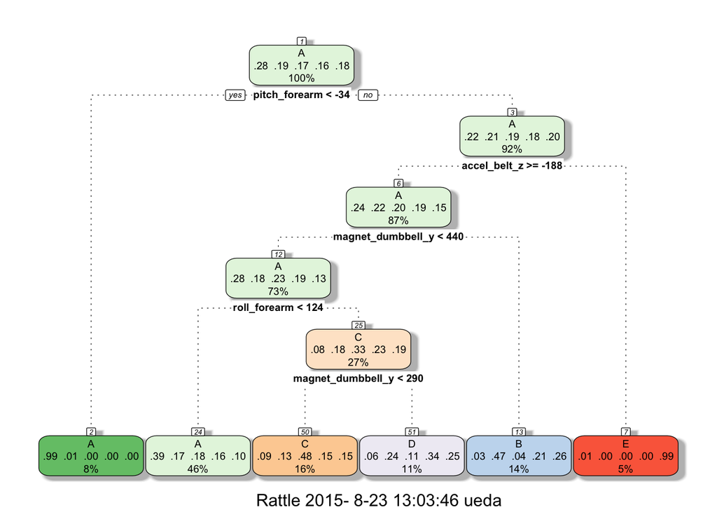

```r
# plot(model1$finalModel, uniform=TRUE, main="Classification Tree")
# text(model1$finalModel, use.n=TRUE, all=TRUE, cex=.8)

#install.packages("rattle")
library(rattle, verbose = FALSE)
fancyRpartPlot(model1$finalModel)
```

## Prediction

The model is applied to the test set pml.testing.

```r
prediction <- predict(model1, newdata=pml.testing)
prediction
```

```
##  [1] C A D A A C D A A A C D C A D A A A A D
## Levels: A B C D E
```

## Submission

First submission shows that only 8 of my prediction is correct.

```r
pml_write_files = function(x){
  n = length(x)
  for(i in 1:n){
    filename = paste0("problem_id_",i,".txt")
    write.table(x[i],file=filename,quote=FALSE,row.names=FALSE,col.names=FALSE,eol = "\r\n")
  }
}
pml_write_files(prediction)
```